# ICT_LIS_661_Project_2_Wiesendanger

# Welcome to Code Chunks!

Our last project `.Rmd` file introduced but didn’t actually use code chunks, so it’s worth touching on those again before we dive back into the project.

Remember that R Markdown is a way for data scientists to share their code **and** write up their research. Regular Markdown features help data scientists format their regular writing, and then *code chunks* display—and run—code alongside writing and commentary.

Here’s what a code chunk looks like:

```r
1 + 1
```

```
## [1] 2
```

When the `.Rmd` document is knit to HTML, not only does the Markdown stuff get formatted, but all of these code chunks are run, so that the code itself **and** the results will appear in the final document. Pretty nifty!

That said, it’s always best to run the code before you knit the file—you know, to make sure the code works properly before you publish it. In that case, you can hit the green “play” button in the top right of the code chunk, and the code will run and display the results—not in the usual console, but in a mini-console attached to the code itself. Try it out on the code-chunk above. You’ll need to run your own code to test it as you work with `.Rmd` documents in this class.

# Welcome to Project 2!

Before moving on, please make a copy of this file and rename it in a way that makes a clear distinction between the original file and the file you’ll eventually submit.

> Under the headers below, I’ll provide you with certain instructions, all of them formatted as blockquotes, like this paragraph is. Under each set of instructions, leave a blank line and then type your (non-blockquoted) response on the line after the blank one. At the very end of this document, I’ll provide instructions for *knitting* and submitting the `.Rmd` to Canvas.

## Project 2, Part 1: Your Dataset [4 points]

> For this project, you will need to identify a dataset with at least 100 observations and 5 variables (at least 3 of which are quantitative). A dataset with at least 1,000 observations and 10 variables would be even better—but not necessary. This does not need to be a publicly available dataset, but please ensure that you can use the dataset legally and ethically. Store the data somewhere in your GitHub repository for this class.

> In the code chunk below, please load the dataset into this document. (Keep in mind that you can—and may need to—load packages as part of this or any other code chunk; however, please do not try to install any packages here). [1 point]

```r
library(tidyverse)
library(here)

# De-identified copy of the Individual Email Results export
# (made with prep_project2_data.R: recipient emails, contact IDs and
#  subscriber IDs removed; only the recipient's email domain is kept)
ier <- read_csv(here("activity_data", "ier_deidentified.csv.gz"),
                show_col_types = FALSE)

# Size of the dataset as loaded (before cleaning adds columns)
n_rows_raw <- nrow(ier)
n_cols_raw <- ncol(ier)
```

> Now that you’ve loaded the dataset, please tell me some about it. Does it have a title? If not, what title would you give it? What reference or citation information (including a public URL, if applicable) can you provide about the dataset? Who created the dataset and when? How did they create it? [1 point]

The dataset doesn’t have a formal title because it is a system export; I would title it **“Individual Email Results (IER), last 7 days.”** It comes from the University of Kentucky’s Salesforce CRM, which records the results of emails sent through Salesforce Marketing Cloud. There is no public URL because this is internal institutional data. The version used here (`activity_data/ier_deidentified.csv.gz` in my class GitHub repository) is a de-identified copy: recipient email addresses, contact IDs and subscriber IDs were removed, and only each recipient’s email domain was kept.

The rows were created automatically by the system as emails were sent, opened, clicked, bounced or unsubscribed from, so each row is triggered by a human action but recorded by software. Send dates run from September 15, 2024 to September 20, 2026, with nearly all of the volume in mid-September 2026.

> What is your interest in this dataset? In general terms, what would you like to know about it? More specifically, what are some possible research questions that you could ask? [1 point]

Possible research questions:

- Do some senders get consistently higher open rates?
- Do larger sends get lower open rates?
- Does the day of the week matter?
- How often do emails bounce, and to which domains?

> As needed, perform any data cleaning (including “tidying” or “wrangling”) on the data in the code chunk below. [1 point]

```r
# 1. Clean, consistent column names
ier <- ier |>
  rename(email_name        = `Individual Email Result: Email Name`,
         batch_id          = BatchID,
         clicked           = Clicked,
         date_bounced      = `Date Bounced`,
         date_sent         = `Date Sent`,
         date_unsubscribed = `Date Unsubscribed`,
         email_asset_id    = `Email Asset ID`,
         email_id          = `Email ID`,
         from_name         = `From Name`,
         hard_bounce       = `Hard Bounce`,
         links_clicked     = `Links Clicked`,
         total_clicks      = `Number of Total Clicks`,
         opened            = Opened)

# 2. Real dates and simple yes/no flags
#    (a blank date_bounced / date_unsubscribed means it did NOT happen)
ier <- ier |>
  mutate(sent_datetime = as.POSIXct(date_sent, format = "%m/%d/%Y, %I:%M %p"),
         sent_date     = as.Date(sent_datetime),
         sent_weekday  = factor(weekdays(sent_date),
                                levels = c("Monday", "Tuesday", "Wednesday",
                                           "Thursday", "Friday", "Saturday", "Sunday")),
         bounced       = !is.na(date_bounced),
         unsubscribed  = !is.na(date_unsubscribed))

# 3. Group recipient domains into a few readable categories
ier <- ier |>
  mutate(domain_group = case_when(
    recipient_domain %in% c("uky.edu", "email.uky.edu")              ~ "UK (uky.edu)",
    recipient_domain == "gmail.com"                                  ~ "Gmail",
    recipient_domain %in% c("icloud.com", "me.com", "mac.com")       ~ "Apple iCloud",
    recipient_domain %in% c("yahoo.com", "aol.com")                  ~ "Yahoo / AOL",
    recipient_domain %in% c("outlook.com", "hotmail.com",
                            "live.com", "msn.com")                   ~ "Microsoft (Outlook/Hotmail)",
    str_detect(recipient_domain, "kyschools\\.us$|k12|isd\\.")   ~ "K-12 school",
    TRUE                                                             ~ "Other"))

# 4. One row per email (campaign), for email-level statistics
email_summary <- ier |>
  group_by(email_name, from_name) |>
  summarize(sends     = n(),
            opens     = sum(opened, na.rm = TRUE),
            clicks    = sum(clicked, na.rm = TRUE),
            bounces   = sum(bounced),
            open_rate = opens / sends,
            .groups   = "drop")

# Emails sent to fewer than 100 people (tests, one-offs) have open rates of
# exactly 0% or 100%, so email-level stats use only the 100+ recipient sends
real_sends <- email_summary |> filter(sends >= 100)
```

## Project 2, Part 2: Summary Statistics [4 points]

> In the code chunk below, write some code that provides a summary of your data. (Please note that while this can include the calculation of summary statistics, you should also use a function that gives you a broader overview of the dataset). As you determine what code to write, consider the specific prompts below. As is typical for R, there are a number of ways to do this—*how* you do so is less important than *that* you do so. [1 point]

```r
# Broad overview: every variable, its type and its first values
glimpse(ier)
```

```
## Rows: 384,024
## Columns: 21
## $ email_name        <chr> "2025 - Graduate School - RFI Journey - Graduate AET and Website RFI", "TRANSFER 9.14.26 WR", "FIRST 9.14.26 WR", "202526 EM Happy B…
## $ batch_id          <dbl> 2509, 8, 7, 14330, 4, 2, 2, 5, 1, 5, 3007, 1009, 198, 256, 245, 5969, 5280, 5012, 5145, 5106, 5284, 5033, 5259, 5629, 5955, 5946, 59…
## $ clicked           <dbl> 0, 0, 0, 0, 0, 0, 0, 0, 0, 0, 0, 0, 0, 0, 0, 0, 0, 0, 0, 0, 0, 0, 0, 0, 0, 0, 0, 0, 0, 0, 0, 0, 0, 0, 0, 0, 0, 0, 0, 0, 0, 0, 0, 0, …
## $ date_bounced      <chr> NA, NA, NA, NA, NA, NA, NA, NA, NA, NA, NA, NA, NA, NA, NA, NA, NA, "9/15/2026, 1:24 PM", NA, NA, NA, NA, NA, NA, NA, NA, NA, NA, NA…
## $ date_sent         <chr> "9/12/2026, 10:51 PM", "9/14/2026, 1:46 PM", "9/14/2026, 2:17 PM", "9/14/2026, 3:01 PM", "9/14/2026, 3:02 PM", "9/14/2026, 3:16 PM",…
## $ date_unsubscribed <chr> NA, NA, NA, NA, NA, NA, NA, NA, NA, NA, NA, NA, NA, NA, NA, NA, NA, NA, NA, NA, NA, NA, NA, NA, NA, NA, NA, NA, NA, NA, NA, NA, NA, …
## $ email_asset_id    <dbl> 6009020, 6083339, 6083340, 6022048, 6082821, 6083342, 6083343, 6083243, 6083168, 6083168, 6083168, 6083168, 6073777, 6073777, 607377…
## $ email_id          <dbl> 137105, 159605, 159606, 140880, 159421, 159608, 159609, 159572, 159545, 159545, 159545, 159545, 156790, 156790, 156790, 156781, 1567…
## $ from_name         <chr> "The Graduate School", "The Wildcat Rundown", "The Wildcat Rundown", "University of Kentucky Admissions", "Meg Marquis", "The Wildca…
## $ hard_bounce       <dbl> 0, 0, 0, 0, 0, 0, 0, 0, 0, 0, 0, 0, 0, 0, 0, 0, 0, 0, 0, 0, 0, 0, 0, 0, 0, 0, 0, 0, 0, 0, 0, 0, 0, 0, 0, 0, 0, 0, 0, 0, 0, 0, 0, 0, …
## $ links_clicked     <dbl> 0, 0, 0, 0, 0, 0, 0, 0, 0, 0, 0, 0, 0, 0, 0, 0, 0, 0, 0, 0, 0, 0, 0, 0, 0, 0, 0, 0, 0, 0, 0, 0, 0, 0, 0, 0, 0, 0, 0, 0, 0, 0, 0, 0, …
## $ total_clicks      <dbl> 0, 0, 0, 0, 0, 0, 0, 0, 0, 0, 0, 0, 0, 0, 0, 0, 0, 0, 0, 0, 0, 0, 0, 0, 0, 0, 0, 0, 0, 0, 0, 0, 0, 0, 0, 0, 0, 0, 0, 0, 0, 0, 0, 0, …
## $ opened            <dbl> 0, 0, 1, 0, 0, 0, 0, 1, 0, 1, 1, 0, 0, 0, 1, 0, 0, 0, 0, 0, 0, 0, 0, 1, 0, 0, 0, 0, 0, 0, 0, 1, 1, 1, 0, 0, 0, 0, 0, 0, 0, 1, 0, 0, …
## $ recipient_domain  <chr> "outlook.com", "uky.edu", "uky.edu", "gmail.com", "uky.edu", "uky.edu", "uky.edu", "uky.edu", "uky.edu", "uky.edu", "uky.edu", "uky.…
## $ sender_domain     <chr> "lifecycle.uky.edu", "lifecycle.uky.edu", "lifecycle.uky.edu", "kentucky.edu", "lifecycle.uky.edu", "lifecycle.uky.edu", "lifecycle.…
## $ sent_datetime     <dttm> 2026-09-12 22:51:00, 2026-09-14 13:46:00, 2026-09-14 14:17:00, 2026-09-14 15:01:00, 2026-09-14 15:02:00, 2026-09-14 15:16:00, 2026-…
## $ sent_date         <date> 2026-09-13, 2026-09-14, 2026-09-14, 2026-09-14, 2026-09-14, 2026-09-14, 2026-09-14, 2026-09-15, 2026-09-15, 2026-09-15, 2026-09-15,…
## $ sent_weekday      <fct> Sunday, Monday, Monday, Monday, Monday, Monday, Monday, Tuesday, Tuesday, Tuesday, Tuesday, Tuesday, Tuesday, Tuesday, Tuesday, Tues…
## $ bounced           <lgl> FALSE, FALSE, FALSE, FALSE, FALSE, FALSE, FALSE, FALSE, FALSE, FALSE, FALSE, FALSE, FALSE, FALSE, FALSE, FALSE, FALSE, TRUE, FALSE, …
## $ unsubscribed      <lgl> FALSE, FALSE, FALSE, FALSE, FALSE, FALSE, FALSE, FALSE, FALSE, FALSE, FALSE, FALSE, FALSE, FALSE, FALSE, FALSE, FALSE, FALSE, FALSE,…
## $ domain_group      <chr> "Microsoft (Outlook/Hotmail)", "UK (uky.edu)", "UK (uky.edu)", "Gmail", "UK (uky.edu)", "UK (uky.edu)", "UK (uky.edu)", "UK (uky.edu…
```

```r
# Base R summary of the quantitative variables
ier |>
  select(opened, clicked, total_clicks, links_clicked, hard_bounce) |>
  summary()
```

```
##      opened          clicked         total_clicks       links_clicked      hard_bounce
##  Min.   :0.0000   Min.   :0.00000   Min.   :   0.0000   Min.   :0.00000   Min.   :0.000000
##  1st Qu.:0.0000   1st Qu.:0.00000   1st Qu.:   0.0000   1st Qu.:0.00000   1st Qu.:0.000000
##  Median :0.0000   Median :0.00000   Median :   0.0000   Median :0.00000   Median :0.000000
##  Mean   :0.2133   Mean   :0.01605   Mean   :   0.0657   Mean   :0.01605   Mean   :0.009281
##  3rd Qu.:0.0000   3rd Qu.:0.00000   3rd Qu.:   0.0000   3rd Qu.:0.00000   3rd Qu.:0.000000
##  Max.   :1.0000   Max.   :1.00000   Max.   :1202.0000   Max.   :1.00000   Max.   :1.000000
```

```r
# Recipient-level summary statistics
recipient_stats <- ier |>
  summarize(recipients        = n(),
            open_rate         = mean(opened, na.rm = TRUE),
            click_rate        = mean(clicked, na.rm = TRUE),
            bounce_rate       = mean(bounced),
            mean_total_clicks = mean(total_clicks, na.rm = TRUE),
            sd_total_clicks   = sd(total_clicks, na.rm = TRUE),
            max_total_clicks  = max(total_clicks, na.rm = TRUE),
            mean_clicks_if_clicked = mean(total_clicks[clicked == 1], na.rm = TRUE))
recipient_stats
```

```
## # A tibble: 1 × 8
##   recipients open_rate click_rate bounce_rate mean_total_clicks sd_total_clicks max_total_clicks mean_clicks_if_clicked
##        <int>     <dbl>      <dbl>       <dbl>             <dbl>           <dbl>            <dbl>                  <dbl>
## 1     384024     0.213     0.0160      0.0185            0.0657            2.10             1202                   4.07
```

```r
# Email-level summary statistics (emails with 100+ recipients)
email_stats <- real_sends |>
  summarize(n_emails     = n(),
            mean_sends   = mean(sends),
            median_sends = median(sends),
            max_sends    = max(sends),
            mean_open    = mean(open_rate),
            sd_open      = sd(open_rate),
            median_open  = median(open_rate),
            iqr_open     = IQR(open_rate),
            min_open     = min(open_rate),
            max_open     = max(open_rate))
email_stats
```

```
## # A tibble: 1 × 10
##   n_emails mean_sends median_sends max_sends mean_open sd_open median_open iqr_open min_open max_open
##      <int>      <dbl>        <dbl>     <int>     <dbl>   <dbl>       <dbl>    <dbl>    <dbl>    <dbl>
## 1       54      7095.         1191    123929     0.394   0.191       0.368    0.215   0.0423    0.857
```

```r
# Open and click rates by recipient domain group
domain_stats <- ier |>
  group_by(domain_group) |>
  summarize(recipients = n(),
            open_rate  = mean(opened, na.rm = TRUE),
            click_rate = mean(clicked, na.rm = TRUE)) |>
  arrange(desc(recipients))
domain_stats
```

```
## # A tibble: 7 × 4
##   domain_group                recipients open_rate click_rate
##   <chr>                            <int>     <dbl>      <dbl>
## 1 UK (uky.edu)                    161010    0.306     0.0198
## 2 Gmail                           121155    0.0251    0.00532
## 3 Other                            39826    0.123     0.0448
## 4 Apple iCloud                     30237    0.615     0.00516
## 5 K-12 school                      21396    0.0964    0.0147
## 6 Yahoo / AOL                       5495    0.366     0.00874
## 7 Microsoft (Outlook/Hotmail)       4905    0.398     0.00612
```

> How many observations and variables are in your dataset? [1 point]

The de-identified dataset has **384,024 observations** (one row per recipient of each email) and **15 variables**. After cleaning, `ier` has 21 variables, including the new date, flag and domain-group columns. Those rows cover **116 different emails**, 54 of which went to 100 or more recipients.

> List and explain 3-5 of the most important quantitative variables. (The quantitative part will become important in the next step!) [1 point]
1. **`opened`** — 1 if the recipient opened the email, 0 if not. Because it is 0/1, its mean is the open rate.
2. **`clicked`** — 1 if the recipient clicked at least one link, 0 if not. Its mean is the click rate.
3. **`total_clicks`** (Number of Total Clicks) — how many times the recipient clicked links in the email, counting repeat clicks.
4. **`sends`** (calculated per email) — how many recipients each email went to, i.e., the size of the send.
5. **`open_rate`** (calculated per email) — the share of an email’s recipients who opened it; this is the main measure of how well an email performed.

> Report on some key summary statistics for the 3-5 variables you identified above. What do those statistics tell you about those variables? [1 point]
- **Opened:** across all recipients, the mean of `opened` is 21.3%, so roughly one in five recipients opened the email they received.
- **Clicked:** the mean of `clicked` is 1.6%. Clicks are much rarer than opens.
- **Total clicks:** the mean is 0.066 (SD 2.1, maximum 1202). Most recipients never click, so the distribution is very right-skewed; among recipients who did click, the average was 4.07 clicks.
- **Sends:** emails with 100+ recipients had a median of 1,191 sends but a mean of 7,095 and a maximum of 123,929. The mean is far above the median because a few very large sends pull it up.
- **Open rate (per email):** mean 39.4%, median 36.8%, standard deviation 19.1 percentage points, IQR 21.5 points, range 4.2% to 85.7%. Open rates vary a lot from email to email.

**What these numbers tell me:**

- **Open rate across all recipients: 21.3%.** Define what makes an email “open” and whether it is automated in any cases. The number seems high, as “open” implies “read,” but it likely is not.
  - *How an open is recorded:* an email platform counts an open when a small invisible tracking image in the email is downloaded. That shows the image loaded, not that a person read the message. Some mail services and security tools load images automatically (see Part 3), and readers with images turned off are never counted.
- **Click rate: 1.6%.** Find a way to unpack this: what was clicked, a link or a button, and to what location does it point?
  - *What this export can and can’t show:* it has click counts per recipient (`total_clicks`, and `links_clicked`, a separate count field), but not which link or button was clicked or its URL. Answering this needs the link-level click data from Marketing Cloud.
- **Total clicks per recipient: mean 0.066, maximum 1,202.** Highlight what is skewing the data:

```r
# Recipients who clicked at least once, most clicks first
clickers <- ier |>
  filter(total_clicks > 0) |>
  arrange(desc(total_clicks))

# The 10 heaviest clickers (de-identified: email, sender and domain group only)
clickers |>
  select(email_name, domain_group, total_clicks, links_clicked) |>
  head(10)
```

```
## # A tibble: 10 × 4
##    email_name                                      domain_group total_clicks links_clicked
##    <chr>                                           <chr>               <dbl>         <dbl>
##  1 202627 EM Early Action App Push 1               Other                1202             1
##  2 202728 OSFAS Scholarship Notification - Initial Gmail                 102             1
##  3 202728 OSFAS Scholarship Notification - Initial Gmail                  62             1
##  4 202728 OSFAS Scholarship Notification - Initial Gmail                  56             1
##  5 202728 OSFAS Scholarship Notification - Initial Other                  55             1
##  6 202728 OSFAS Scholarship Notification - Initial Gmail                  47             1
##  7 202728 OSFAS Scholarship Notification - Initial Gmail                  46             1
##  8 202728 OSFAS Scholarship Notification - Initial Other                  45             1
##  9 202627 EM Early Action App Push 2- BBN          Other                  42             1
## 10 202627 EM Early Action App Push 1               Other                  39             1
```

```r
# How concentrated are clicks?
click_concentration <- clickers |>
  summarize(clickers           = n(),
            all_clicks         = sum(total_clicks),
            median_clicks      = median(total_clicks),
            top10_share        = sum(head(total_clicks, 10)) / all_clicks,
            top1pct_share      = sum(head(total_clicks, ceiling(n() / 100))) / all_clicks,
            clickers_over_20   = sum(total_clicks > 20))
click_concentration
```

```
## # A tibble: 1 × 6
##   clickers all_clicks median_clicks top10_share top1pct_share clickers_over_20
##      <int>      <dbl>         <dbl>       <dbl>         <dbl>            <int>
## 1     6170      25219             2      0.0673         0.131               89
```

```r
# Heavy clickers (more than 20 clicks) by domain group
heavy_by_domain <- clickers |>
  filter(total_clicks > 20) |>
  count(domain_group, sort = TRUE)
heavy_by_domain
```

```
## # A tibble: 6 × 2
##   domain_group                    n
##   <chr>                       <int>
## 1 Other                          64
## 2 Gmail                          14
## 3 UK (uky.edu)                    5
## 4 K-12 school                     4
## 5 Microsoft (Outlook/Hotmail)     1
## 6 Yahoo / AOL                     1
```

*What the data shows:* 6,170 recipients clicked at least once, and the typical (median) clicker clicked 2 time(s). But the 10 heaviest clickers alone account for 6.7% of all 25,219 clicks, and the top 1% of clickers account for 13.1%. Most clickers click only once or twice, so a relatively small group of heavy clickers pulls the average up: 89 recipients clicked more than 20 times, and 64 of them are in the “Other” domain group, the same group with the highest click rate in Part 3. The single most extreme row has 1,202 clicks on one email; counts that high are more likely automated link scanning than a person.

## Project 2, Part 3: Visualization [2 points]

> In the code chunk below, pick one or more of the variables in your dataset, choose an appropriate visualization for the variable(s), and carry that visualization out. [1 point]

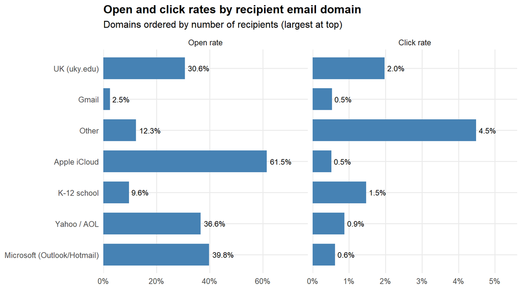

```r
# Open and click rates by recipient domain group (pre-counted -> geom_col).
# Tidy the two rates into one column so each can get its own facet;
# click rates are ~10x smaller, so each facet gets its own x-axis.
domain_rates_tidy <- domain_stats |>
  pivot_longer(cols = c(open_rate, click_rate),
               names_to = "metric", values_to = "rate") |>
  mutate(metric = recode(metric, open_rate = "Open rate", click_rate = "Click rate"),
         metric = factor(metric, levels = c("Open rate", "Click rate")),
         domain_group = fct_reorder(domain_group, recipients))

ggplot(domain_rates_tidy, aes(x = rate, y = domain_group)) +
  geom_col(fill = "steelblue", width = 0.7) +
  geom_text(aes(label = scales::percent(rate, accuracy = 0.1)),
            hjust = -0.15, size = 3.3) +
  facet_wrap(~ metric, scales = "free_x") +
  scale_x_continuous(labels = scales::label_percent(accuracy = 1),
                     expand = expansion(mult = c(0, 0.25))) +
  labs(title = "Open and click rates by recipient email domain",
       subtitle = "Domains ordered by number of recipients (largest at top)",
       x = NULL, y = NULL) +
  theme_minimal(base_size = 12) +
  theme(panel.grid.minor = element_blank(),
        plot.title = element_text(face = "bold"))
```

> Here, explain what you were trying to learn about the data, what kind of plot you chose, why that plot is important for what you were trying to learn, and what the plot showed about the data. [1 point]

Understand how providers are impacting results.

```r
domain_stats |>
  mutate(open_rate  = scales::percent(open_rate, accuracy = 0.1),
         click_rate = scales::percent(click_rate, accuracy = 0.1),
         recipients = format(recipients, big.mark = ",")) |>
  knitr::kable(col.names = c("Domain group", "Recipients", "Open rate", "Click rate"),
               align = c("l", "r", "r", "r"))
```

| Domain group | Recipients | Open rate | Click rate |
| --- | --- | --- | --- |
| UK (uky.edu) | 161,010 | 30.6% | 2.0% |
| Gmail | 121,155 | 2.5% | 0.5% |
| Other | 39,826 | 12.3% | 4.5% |
| Apple iCloud | 30,237 | 61.5% | 0.5% |
| K-12 school | 21,396 | 9.6% | 1.5% |
| Yahoo / AOL | 5,495 | 36.6% | 0.9% |
| Microsoft (Outlook/Hotmail) | 4,905 | 39.8% | 0.6% |

### Follow-up

#### To do 1: Get to the bottom of what each provider is doing with our sends

**Goal:** for each major provider, know whether our opens and clicks are real human activity, machine activity, or missing.

- **Apple iCloud (61.5% opens, 0.5% clicks).** Check how much of this is Apple Mail Privacy Protection, which loads email images (including the open-tracking pixel) on Apple’s servers whether or not the person reads the email. Opens that are high while clicks match other providers fit this pattern.
- **Gmail (2.5% opens, 0.5% clicks).** Find out why opens are this low when clicks are in line with other providers. Things to check:
  - Is the email being **clipped**? Gmail cuts off long messages (“[Message clipped]”), and if the tracking pixel is below the cut, no open is recorded. Check the size of our largest templates.
  - Are images (and so the pixel) being blocked or not loaded for many recipients?
  - Are sends landing in the **Promotions** tab or spam? Check deliverability and inbox placement for Gmail specifically.
  - Confirm the tracking pixel is present and placed correctly in the templates sent to Gmail.
- **“Other” (4.5% clicks, the highest of any group).** Check for **automated link scanning**: security gateways and filters at organizations often “click” every link to check it for safety. One recipient row has **1,202 clicks**, which is not human.
  - List the top domains inside “Other” and their click rates.
  - Look at recipients with very high click counts or clicks on every link.
- **UK (uky.edu).** UK mail runs through Microsoft 365. Check whether Microsoft’s link and attachment scanning (Safe Links / Defender) is creating opens or clicks before people see the email.
- **K-12 school domains (9.6% opens).** Check whether school filters are blocking images, quarantining, or delaying our mail.
- **Bounces by provider.** Break bounces down by domain group to see if any provider is rejecting our mail at higher rates.
- Ask the Marketing Cloud admin / deliverability team whether Marketing Cloud already flags machine opens or bot clicks, and if so, whether that flag can be added to the IER export.

#### To do 2: Review, then act on these suggestions

**Review first:** go over the Project 2 results (`project_2/ICT_LIS_661_Project_2_Wiesendanger.html`) and the table above with the team, and agree on which numbers we trust.

Suggestions:

1. **Make click rate the main success measure across providers** until we understand opens better. It was the more consistent of the two (0.5%–2.0% for the major providers), while open rates ranged from 2.5% to 61.5%.
2. **Report results by domain group, not just overall.** An overall 21.3% open rate mixes Apple’s inflated opens with Gmail’s missing ones.
3. **Add fields to the IER export** that would let us separate machine activity from people:
   - date/time of open and of click (machine activity often happens within seconds of the send),
   - device / mail client and user agent, if available,
   - any bot or machine-open flag the platform provides.
4. **Filter out likely bot clicks** before reporting (for example, a click on every link within seconds of delivery, or extreme click counts like the 1,202 row).
5. **Check Gmail template size and pixel placement** so opens aren’t lost to clipping.
6. **Use only emails with 100+ recipients** when comparing email performance; small and test sends produce 0% or 100% rates that distort averages.
7. **Don’t read too much into weekday patterns yet.** Nearly all volume falls in one week, so each weekday is really one day, and Tuesday’s low rate comes mostly from one very large send. Collect several weeks before comparing days.
8. **Re-run the analysis on a longer export** (several weeks or a full term) using the same scripts (`prep_project2_data.R`, the Project 2 `.Rmd`), so trends aren’t driven by a single send.

#### To do 3: Understand what an “open” is and isn’t

**Goal:** a shared, plain-language definition the team uses when reporting.

**What an open is:** an email platform records an “open” when a tiny invisible image (a tracking pixel) in the email is downloaded. That’s all it measures: the image was loaded.

**What an open is not:**

- **Not proof a person read the email.** Apple Mail Privacy Protection and some security scanners load the pixel automatically.
- **Not a full count of readers.** If images are blocked, the email is clipped, or someone reads the plain-text version, a real reader may never register an open.
- **Not comparable across providers** without adjusting for how each one handles images (see To do 1).

Things to confirm for our setup:

- Is our IER `Opened` field **unique** (opened at least once) or a count of all opens? (In this export it is 0/1.)
- Does Marketing Cloud count a **click as an “implied open”** when no pixel loaded? If yes, some opens are really clicks.
- Are **forwarded** emails counted against the original recipient?
- Write a one-paragraph team definition of “open,” “click” and “click-to-open rate,” and add it to our reporting notes.

## Summary: What Each Provider Is Doing With Our Emails

**About this sample.** The data is a de-identified export of Individual Email Results from Salesforce Marketing Cloud, sent between September 15, 2024 and September 20, 2026, with 99% of sends in the final week (September 14–September 20, 2026). It covers **116 unique emails** from 50 University of Kentucky senders (offices such as the Graduate School, Financial Aid, Admissions and student-success programs), totaling **384,024 sends**, one row per recipient. Recipients fall into these broad groups by email domain: UK (uky.edu) (161,010), Gmail (121,155), Other (39,826), Apple iCloud (30,237), K-12 school (21,396), Yahoo / AOL (5,495), Microsoft (Outlook/Hotmail) (4,905).

The open and click rates above don’t tell the whole story on their own, so this table adds a few more measures for each provider:

- **Click-to-open rate:** clicks divided by opens. When it is very low, opens are probably inflated; when it is very high, opens are probably undercounted.
- **Clickers with no recorded open:** a person has to open an email to click it, so a click with no open means the tracking image never loaded. A high share is a sign of **automated link scanners** (security tools that “click” every link to check it) or blocked images.
- **Bounce rates** and **heavy clickers** (recipients with more than 20 clicks).

```r
provider_detail <- ier |>
  group_by(domain_group) |>
  summarize(recipients           = n(),
            open_rate            = mean(opened, na.rm = TRUE),
            click_rate           = mean(clicked, na.rm = TRUE),
            click_to_open        = sum(clicked, na.rm = TRUE) / sum(opened, na.rm = TRUE),
            clickers_no_open     = mean(opened[clicked == 1] == 0, na.rm = TRUE),
            bounce_rate          = mean(bounced),
            hard_bounce_rate     = mean(hard_bounce, na.rm = TRUE),
            clicks_per_clicker   = mean(total_clicks[clicked == 1], na.rm = TRUE),
            heavy_clickers       = sum(total_clicks > 20, na.rm = TRUE)) |>
  arrange(desc(recipients))

# helper for quoting values in the text below
pv <- function(group, col, digits = 1) {
  scales::percent(provider_detail[[col]][provider_detail$domain_group == group],
                  accuracy = 10^-digits)
}

provider_detail |>
  mutate(across(c(open_rate, click_rate, click_to_open, clickers_no_open,
                  bounce_rate, hard_bounce_rate),
                ~ scales::percent(.x, accuracy = 0.1)),
         clicks_per_clicker = round(clicks_per_clicker, 1),
         recipients = format(recipients, big.mark = ",")) |>
  knitr::kable(col.names = c("Provider", "Recipients", "Open rate", "Click rate",
                             "Click-to-open", "Clickers w/ no open", "Bounce rate",
                             "Hard bounce", "Clicks per clicker", "Heavy clickers"),
               align = c("l", rep("r", 9)))
```

| Provider | Recipients | Open rate | Click rate | Click-to-open | Clickers w/ no open | Bounce rate | Hard bounce | Clicks per clicker | Heavy clickers |
| --- | --- | --- | --- | --- | --- | --- | --- | --- | --- |
| UK (uky.edu) | 161,010 | 30.6% | 2.0% | 6.4% | 20.3% | 0.0% | 0.0% | 2.3 | 5 |
| Gmail | 121,155 | 2.5% | 0.5% | 21.2% | 1.7% | 0.7% | 0.1% | 5.4 | 14 |
| Other | 39,826 | 12.3% | 4.5% | 36.4% | 77.7% | 5.6% | 3.4% | 6.4 | 64 |
| Apple iCloud | 30,237 | 61.5% | 0.5% | 0.8% | 5.8% | 4.1% | 0.2% | 4.3 | 0 |
| K-12 school | 21,396 | 9.6% | 1.5% | 15.3% | 73.3% | 12.3% | 8.8% | 6.3 | 4 |
| Yahoo / AOL | 5,495 | 36.6% | 0.9% | 2.4% | 2.1% | 1.3% | 1.1% | 4.4 | 1 |
| Microsoft (Outlook/Hotmail) | 4,905 | 39.8% | 0.6% | 1.5% | 0.0% | 0.4% | 0.1% | 3.3 | 1 |

**One caution before reading by provider:** the domain is also a stand-in for *who* the audience is. UK addresses are mostly current students, faculty and staff, while Gmail, iCloud and K-12 addresses are more often prospective students and families. Some differences below are about the audience, not the provider. This sample is also mostly one week of sends, so these are patterns to investigate (see the follow-up to-dos above), not proven causes.

### By provider

**UK (uky.edu, Microsoft 365)** — open rate 30.6%, click rate 2.0%, bounce rate 0.04%.

- *What the data suggests:* the healthiest, most “normal” numbers. Mail is delivered almost every time, and clickers average only 2.3 clicks each, which looks like real people.
- *Watch:* 20.3% of UK clickers have no recorded open. That points to images not loading in Outlook for some readers and/or Microsoft’s link scanning (Safe Links).
- *Impact:* opens are **somewhat undercounted** and clicks are **mostly reliable**.

**Gmail** — open rate 2.5%, click rate 0.5%, bounce rate 0.69%.

- *What the data suggests:* only 1.7% of Gmail clickers lack an open, so when Gmail users engage, tracking works. That makes “Gmail is hiding our opens” less likely as the main explanation. The low open **and** low click rates point instead to **inbox placement** (mail landing in the Promotions tab or spam) and/or a less engaged audience of personal addresses. Gmail’s message clipping is still worth ruling out for long templates.
- *Impact:* both opens and clicks are **low but probably real**. Gmail is the biggest opportunity: it is the second-largest group (121,155 recipients) with the weakest engagement.

**Apple iCloud** — open rate 61.5%, click rate 0.5%, click-to-open 0.8%.

- *What the data suggests:* the highest open rate but one of the lowest click rates, so fewer than 1 in 100 “opens” leads to a click. This fits **Apple Mail Privacy Protection**, which loads the tracking image automatically. There are no heavy clickers, so clicks look human.
- *Also:* a 4.1% bounce rate, mostly not hard bounces (0.21%), which suggests temporary delivery problems worth checking.
- *Impact:* opens are **heavily inflated**; clicks are **reliable**.

**Microsoft (Outlook/Hotmail)** and **Yahoo / AOL** — open rates 39.8% and 36.6%; click rates 0.6% and 0.9%.

- *What the data suggests:* fairly high opens with low click-to-open rates (1.5% and 2.4%), a milder version of the Apple pattern. Some opens may be automatic image loading. Almost all clickers have an open on record.
- *Also:* these two groups have the highest unsubscribe rates in the sample, though the numbers are small.
- *Impact:* opens are **possibly inflated**; clicks are **mostly reliable**. These are small groups (about 5,000 recipients each), so treat their rates with caution.

**K-12 school domains** — open rate 9.6%, click rate 1.5%, bounce rate 12.3%.

- *What the data suggests:* the biggest **deliverability** problem in the sample: 12.3% of messages bounced, 8.8% permanently (hard bounces). And 73.3% of clickers have no recorded open, a strong sign that school email filters are scanning links and blocking images.
- *Impact:* opens are **undercounted** (images blocked), clicks are **partly automated**, and many messages **never arrive**. Cleaning up hard-bounced K-12 addresses would help.

**Other domains** — open rate 12.3%, click rate 4.5%, bounce rate 5.6%.

- *What the data suggests:* the highest click rate is **mostly not people**. 77.7% of clickers never registered an open, clickers average 6.4 clicks each, and this group has 64 of the 89 heavy clickers, including the 1,202-click row. This is the fingerprint of **corporate and institutional security scanners**. It also has high bounce rates (3.4% hard).
- *Impact:* clicks are **heavily inflated**; opens are **undercounted**.

### Overall

| Provider | Opens are probably… | Clicks are probably… | Main issue |
| --- | --- | --- | --- |
| UK (uky.edu) | somewhat undercounted | reliable | images off / link scanning for some readers |
| Gmail | low but real | low but real | inbox placement / engagement |
| Apple iCloud | heavily inflated | reliable | Apple Mail Privacy Protection |
| Microsoft, Yahoo / AOL | possibly inflated | mostly reliable | small groups; some automatic opens |
| K-12 school | undercounted | partly automated | bounces and school filters |
| Other | undercounted | heavily inflated | security scanners clicking links |

Taken together, **neither the overall open rate nor the overall click rate means what it appears to.** Apple inflates opens while K-12 and “Other” domains hide them, and scanners inflate clicks in exactly the groups where opens are missing. The most trustworthy measure in this sample is **click rate for UK, Gmail, Apple, Microsoft and Yahoo recipients**. Opens should be reported by provider, with Apple opens and scanner clicks flagged or excluded.

# Submitting Project 2

After you’ve completed all parts of this assignment to your satisfaction, click on the `Knit` button in the toolbar at the top of this pane. When/if prompted, please indicate that you wish to knit to an HTML file. Knitting to PDF or Word are fancy tricks but take some more setting up, and that’s beyond the scope of this class.

After RStudio has finished knitting the file, it will bring it up in a special RStudio interface. **You should use this interface to review the document and make sure that everything appears as you want.** Then, however, you should navigate to the same folder where you have stored this `.Rmd` file, and you will find a `.html` file with the same name in that same folder. You can open that file to view this in your browser; more importantly, this is the file that you should submit to Canvas to complete this assignment.

I cannot accept any submission of your work besides the knit `.html` file! If you are having trouble knitting, please get in touch with me instead of submitting the `.Rmd` file and hoping it will work instead. Likewise, please don’t attempt to manually convert this `.Rmd` file into an `.html` file—that will not work either.

Speaking of having your data, though, it would be nice to have access to all the work you’ve done in addition to the `.html` file. Please open GitHub desktop, navigate to your repository for this class, *commit* the changes that you’ve made in completing this project, and *push* those changes to GitHub. I will also ask you to do this if you need any help along the way.